### Students:

- Name: Ronen Shershnev ID: 322217175
- Name: Vladislav Pavlyuk ID: 332294891

# Homework 2 - Embeddings

A comparative study of four text-embedding methods on English Wikipedia texts.

**Corpus:** 5 real English Wikipedia excerpts (≥300 words) + 5 Claude-generated texts on the same 5 topics (≥300 words, deliberately **restricted vocabulary**). **Topics:** Photosynthesis & Cellular respiration (biology pair), Jazz & Blues (music pair), Mount Everest (outlier). **Methods:** Bag-of-Words, TF-IDF, FastText (gensim), MiniLM (`all-MiniLM-L6-v2`).

### Methodology decisions (resolving the ambiguity in section 4)

- **Sizing to 30 / 300 dims:** BoW/TF-IDF via `max_features`; FastText via gensim `vector_size`; MiniLM (384-d) via **PCA** to 30/300.
- **PCA bases are fit on a ~2,250-sentence pool** (full articles + generated texts), never on the 10 documents alone (10 samples → ≤9 components). This is the reusable PCA used again in section 7.
- **Document vector** = BoW/TF-IDF row · FastText mean-of-word-vectors · MiniLM mean-of-sentence-embeddings then PCA.
- **Joint fitting**: each method is fit once on all 10 docs (shared space); the "2 sources" axis is a partition → the 16 sets.
- **Metric:** cosine similarity throughout.

> This notebook reuses the functions in `src/`. The same results are produced by `python -m src.run_all`. A fuller write-up is in `REPORT.md`.

## Setup

```python
import sys, os, json, warnings
from pathlib import Path
warnings.filterwarnings("ignore")

# Make `import src...` work regardless of where Jupyter started.
ROOT = Path.cwd()
if not (ROOT / "src").exists() and (ROOT.parent / "src").exists():
    ROOT = ROOT.parent
os.chdir(ROOT); sys.path.insert(0, str(ROOT))

import numpy as np, pandas as pd
from IPython.display import Image, Markdown, display

from src import config, analysis, embeddings, manual_walkthrough, probes
from src.corpus import load_documents
from src.text_utils import word_count, tokenize_words
print("repo root:", ROOT)
```

```
repo root: NLP2HW
```

## 1 - Data collection

5 English Wikipedia articles fetched via the MediaWiki action API (`src/data_collection.py`), cleaned, and cut to ≥300-word excerpts. Each saved text is the current-revision article lead.

**Sources (English Wikipedia):**

- Photosynthesis - https://en.wikipedia.org/wiki/Photosynthesis
- Cellular respiration - https://en.wikipedia.org/wiki/Cellular_respiration
- Jazz - https://en.wikipedia.org/wiki/Jazz
- Blues - https://en.wikipedia.org/wiki/Blues
- Mount Everest - https://en.wikipedia.org/wiki/Mount_Everest

```python
from src import data_collection
need = [config.ORIGINAL_DIR / f"wiki_{i:02d}_{s}.txt"
        for i, (s, _, _) in enumerate(config.TOPICS, 1)]
if not all(p.exists() for p in need):
    data_collection.main()           # fetches from Wikipedia (needs network)

docs = load_documents()
display(pd.DataFrame([{"idx": d.idx, "source": d.source, "topic": d.slug,
                       "domain": d.domain, "words": word_count(d.text)}
                      for d in docs]))
print("\\nSample excerpt (original photosynthesis):\\n")
print(docs[0].text[:400], "...")
```

|  | idx | source | topic | domain | words |
| --- | --- | --- | --- | --- | --- |
| 0 | 0 | original | photosynthesis | biology | 327 |
| 1 | 1 | original | cellular_respiration | biology | 300 |
| 2 | 2 | original | jazz | music | 305 |
| 3 | 3 | original | blues | music | 311 |
| 4 | 4 | original | mount_everest | geography | 306 |
| 5 | 5 | generated | photosynthesis | biology | 315 |
| 6 | 6 | generated | cellular_respiration | biology | 316 |
| 7 | 7 | generated | jazz | music | 320 |
| 8 | 8 | generated | blues | music | 317 |
| 9 | 9 | generated | mount_everest | geography | 318 |

```
\nSample excerpt (original photosynthesis):\n
Photosynthesis is a system of biological processes by which photopigment-bearing autotrophic organisms, such as most plants, algae and cyanobacteria, convert light energy — typically from sunlight — into the chemical energy necessary to fuel their metabolism. The term photosynthesis usually refers t…
```

## 2 - AI-generated texts (restricted vocabulary)

Generated with Claude using the exact prompt below, which **explicitly demands as limited a vocabulary as possible** (the graded constraint). Evidence that it worked: the generated texts have a much lower type-token ratio (unique/total words) than the originals.

```python
print(config.GEN_PROMPT_FILE.read_text())
```

```
SYSTEM / INSTRUCTION PROMPT SENT TO THE LANGUAGE MODEL (Claude)
================================================================
(Section 2 requires that the prompt explicitly ask the model to use as
LIMITED / RESTRICTED a vocabulary as possible. This is the exact prompt used.)

You are writing a short, encyclopedia-style explanatory article in English about
the topic: "{TOPIC}".

HARD CONSTRAINT - RESTRICTED VOCABULARY:
Write using as small and as limited a vocabulary as you possibly can.
- Use only simple, very common everyday English words (roughly the most common
  ~1000 words a child would know).
- Do NOT use technical terms, scientific names, jargon, or "fancy"/sophisticated
  words. If a hard word is unavoidable, immediately re-explain it with simple words.
- Prefer repeating the SAME simple words over reaching for synonyms. Reusing
  plain words many times is encouraged, not penalized.
- Keep sentences short and plain. Avoid rare adjectives and adverbs.

CONTENT CONSTRAINTS:
- Stay factually correct and on-topic, in a neutral encyclopedic tone.
- Length: at least 300 words.
- Plain prose only: no headings, no bullet points, no markdown, no references.

Write the article now.
```

```python
def ttr(text):
    w = tokenize_words(text); return len(set(w)) / len(w)

rows = []
for i, (slug, _, _) in enumerate(config.TOPICS, 1):
    o = (config.ORIGINAL_DIR / f"wiki_{i:02d}_{slug}.txt").read_text()
    g = (config.GENERATED_DIR / f"wiki_gen_{i:02d}_{slug}.txt").read_text()
    rows.append({"topic": slug, "original_TTR": ttr(o), "generated_TTR": ttr(g)})
pd.DataFrame(rows).round(3)
```

|  | topic | original_TTR | generated_TTR |
| --- | --- | --- | --- |
| 0 | photosynthesis | 0.609 | 0.375 |
| 1 | cellular_respiration | 0.483 | 0.380 |
| 2 | jazz | 0.593 | 0.459 |
| 3 | blues | 0.543 | 0.461 |
| 4 | mount_everest | 0.556 | 0.421 |

## 3 + 4 - The 16 embedding sets

4 methods × 2 sizes (30, 300) × 2 sources = **16 sets** (`src/embeddings.py` → `data/embeddings/`). Building trains FastText and encodes the sentence pool with MiniLM (~1 minute the first time).

Each of the 10 texts is represented as a single **document vector** by aggregating its word vectors (BoW/TF-IDF rows; mean-pooled FastText/MiniLM); explicit per-word vectors are demonstrated by hand in section 8.

```python
if not embeddings.ARTIFACTS_PATH.exists():
    embeddings.main()
art = analysis.load_artifacts()

manifest = json.loads((config.EMB_DIR / "manifest.json").read_text())
print(f"{len(manifest)} embedding sets in manifest")
print("MiniLM PCA explained variance:", art["meta"]["pca"])
display(pd.DataFrame(manifest).pivot_table(
    index=["method", "dim"], columns="source", values="shape", aggfunc="first"))
```

```
16 embedding sets in manifest
MiniLM PCA explained variance: {'minilm_30': {'explained_var': 0.5181, 'padded': False, 'n_pool': 2251}, 'minilm_300': {'explained_var': 0.9918, 'padded': False, 'n_pool': 2251}}
```

| method | source dim | generated | original |
| --- | --- | --- | --- |
| bow | 30 | [5, 30] | [5, 30] |
|  | 300 | [5, 300] | [5, 300] |
| fasttext | 30 | [5, 30] | [5, 30] |
|  | 300 | [5, 300] | [5, 300] |
| minilm | 30 | [5, 30] | [5, 30] |
|  | 300 | [5, 300] | [5, 300] |
| tfidf | 30 | [5, 30] | [5, 30] |
|  | 300 | [5, 300] | [5, 300] |

## 5 - Method comparison (2 research questions)

**Q1 - sensitive to shared/overlapping words?** `lex_corr` = Pearson r between cosine similarity and Jaccard *word* overlap over all 45 document pairs (high ⇒ similarity is driven by shared words).

**Q2 - semantic similarity without literal overlap?** `xtopic_cos` = mean cosine of the 5 same-topic **original↔generated** pairs, which share only ~14 % of words (`xtopic_jaccard`) yet mean the same thing (high ⇒ method sees meaning).

|  | method | dim | lex_corr(Q1) | xtopic_cos(Q2) | xtopic_jaccard |
| --- | --- | --- | --- | --- | --- |
| 0 | bow | 30 | 0.396 | 0.828 | 0.143 |
| 1 | bow | 300 | 0.433 | 0.692 | 0.143 |
| 2 | tfidf | 30 | 0.285 | 0.752 | 0.143 |
| 3 | tfidf | 300 | 0.543 | 0.469 | 0.143 |
| 4 | fasttext | 30 | 0.793 | 0.920 | 0.143 |
| 5 | fasttext | 300 | 0.797 | 0.919 | 0.143 |
| 6 | minilm | 30 | 0.446 | 0.771 | 0.143 |
| 7 | minilm | 300 | 0.475 | 0.657 | 0.143 |

```
  wrote NLP2HW/results/heatmaps_dim300.png
```

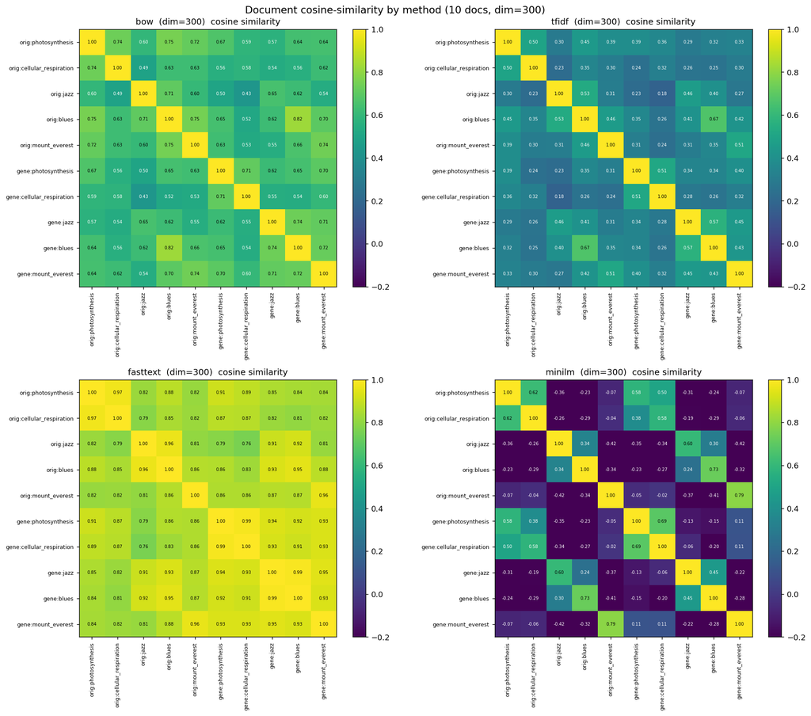

```python
tok = analysis.doc_token_sets(load_documents())
he = analysis.section_he(art, tok)
display(he)
analysis.make_heatmaps(art, dim=300)
display(Image(str(config.RESULTS_DIR / "heatmaps_dim300.png")))
```

## 6 - Effect of embedding size

**Topic-separation score** on a source's 5 docs = mean cosine of same-domain close pairs − mean cosine of the other pairs (higher = better). This is the "quality" metric (it directly measures whether related texts cluster and unrelated ones separate), used consistently here and in section 7. The effect of length on section 5's own metrics (lex_corr, xtopic_cos) is also visible directly in the 5 table above, which lists every method at both dim=30 and dim=300.

```python
display(analysis.section_vav(art))
```

|  | method | sep@30_orig | sep@300_orig | sep@30_gene | sep@300_gene |
| --- | --- | --- | --- | --- | --- |
| 0 | bow | 0.049 | 0.076 | 0.056 | 0.087 |
| 1 | tfidf | 0.125 | 0.168 | 0.149 | 0.190 |
| 2 | fasttext | 0.145 | 0.140 | 0.057 | 0.057 |
| 3 | minilm | 0.824 | 0.732 | 0.767 | 0.673 |

**Finding.** Bigger is **not** uniformly better. BoW/TF-IDF improve with more dimensions (they need vocabulary features to tell topics apart), but **MiniLM separates topics *better* at 30-dim than 300-dim** (0.824 → 0.732): the first PCA components hold the dominant semantic axes, extra dims add noise.

## 7 - PCA reduction (300 → 30) vs native-30

For each method, reduce the 300-dim doc vectors to 30 with PCA (basis fit on the method's atom pool) and compare to native-30.

```python
display(analysis.section_zayin(art, tok))
```

|  | method | variant | lex_corr | xtopic_cos | sep_orig | pca_explVar |
| --- | --- | --- | --- | --- | --- | --- |
| 0 | bow | native30 | 0.396 | 0.828 | 0.049 |  |
| 1 | bow | pca300to30 | 0.657 | 0.832 | 0.095 | 0.701 |
| 2 | bow | native300 | 0.433 | 0.692 | 0.076 |  |
| 3 | tfidf | native30 | 0.285 | 0.752 | 0.125 |  |
| 4 | tfidf | pca300to30 | 0.645 | 0.487 | 0.395 | 0.5 |
| 5 | tfidf | native300 | 0.543 | 0.469 | 0.168 |  |
| 6 | fasttext | native30 | 0.793 | 0.920 | 0.145 |  |
| 7 | fasttext | pca300to30 | 0.823 | 0.530 | 0.861 | 0.919 |
| 8 | fasttext | native300 | 0.797 | 0.919 | 0.140 |  |
| 9 | minilm | pca384→30 | 0.446 | 0.771 | 0.824 |  |
| 10 | minilm | pca300to30 | 0.445 | 0.772 | 0.824 | 0.521 |
| 11 | minilm | pca384→300 | 0.475 | 0.657 | 0.732 |  |

**Finding.** For lexical/word methods, **PCA-from-300 clearly beats native top-30** at separating topics (TF-IDF 0.13→0.40, FastText 0.15→0.86): *feature extraction* (rich linear combinations) beats *feature selection* (the 30 commonest words, mostly stopwords). For MiniLM the two 30-dim variants are essentially identical (both PCA of the same 384-dim space). So **how** you get 30 dims matters more than the number 30.

## 8 - Manual BoW / TF-IDF / cosine walkthrough

Three sentences from the generated photosynthesis text, worked **by hand**: vocabulary, count matrix, TF/IDF/TF·IDF, L2 normalization, and cosine between word *column* vectors - each step shown, then cross-checked against scikit-learn.

```python
manual_walkthrough.main()
display(Markdown((config.RESULTS_DIR / "section_het_manual.md").read_text()))
```

```
wrote NLP2HW/results/section_het_manual.md
sklearn cross-check: BoW=True  TF-IDF=True
```

Section 8 - Manual BoW / TF-IDF / Cosine Walkthrough

Three sentences taken verbatim from `data/generated/wiki_gen_01_photosynthesis.txt`:

- **S1:** "Plants make their own food."

- **S2:** "They make this food from sunlight, water, and air."

- **S3:** "The green parts of a plant, like the leaves, do most of this work."

**Tokenization** (lowercase, alphabetic tokens only):

- S1 → ['plants', 'make', 'their', 'own', 'food']

- S2 → ['they', 'make', 'this', 'food', 'from', 'sunlight', 'water', 'and', 'air']

- S3 → ['the', 'green', 'parts', 'of', 'a', 'plant', 'like', 'the', 'leaves', 'do', 'most', 'of', 'this', 'work']

**Vocabulary** (sorted, 23 terms): `['a', 'air', 'and', 'do', 'food', 'from', 'green', 'leaves', 'like', 'make', 'most', 'of', 'own', 'parts', 'plant', 'plants', 'sunlight', 'the', 'their', 'they', 'this', 'water', 'work']`

1. Bag-of-Words (counting by hand)

Each cell = number of times the term occurs in the sentence.

| doc | a | air | and | do | food | from | green | leaves | like | make | most | of | own | parts | plant | plants | sunlight | the | their | they | this | water | work |
| --- | --- | --- | --- | --- | --- | --- | --- | --- | --- | --- | --- | --- | --- | --- | --- | --- | --- | --- | --- | --- | --- | --- | --- |
| S1 | 0 | 0 | 0 | 0 | 1 | 0 | 0 | 0 | 0 | 1 | 0 | 0 | 1 | 0 | 0 | 1 | 0 | 0 | 1 | 0 | 0 | 0 | 0 |
| S2 | 0 | 1 | 1 | 0 | 1 | 1 | 0 | 0 | 0 | 1 | 0 | 0 | 0 | 0 | 0 | 0 | 1 | 0 | 0 | 1 | 1 | 1 | 0 |
| S3 | 1 | 0 | 0 | 1 | 0 | 0 | 1 | 1 | 1 | 0 | 1 | 2 | 0 | 1 | 1 | 0 | 0 | 2 | 0 | 0 | 1 | 0 | 1 |

2. TF-IDF (step by step)

**TF** = raw count above. **DF** = #sentences containing the term. **IDF** = ln((1+N)/(1+DF)) + 1, with N = 3 (smoothed, as in scikit-learn).

| term | DF | IDF |
| --- | --- | --- |
| a | 1 | ln((1+3)/(1+1))+1 = 1.6931 |
| air | 1 | ln((1+3)/(1+1))+1 = 1.6931 |
| and | 1 | ln((1+3)/(1+1))+1 = 1.6931 |
| do | 1 | ln((1+3)/(1+1))+1 = 1.6931 |
| food | 2 | ln((1+3)/(1+2))+1 = 1.2877 |
| from | 1 | ln((1+3)/(1+1))+1 = 1.6931 |
| green | 1 | ln((1+3)/(1+1))+1 = 1.6931 |
| leaves | 1 | ln((1+3)/(1+1))+1 = 1.6931 |
| like | 1 | ln((1+3)/(1+1))+1 = 1.6931 |
| make | 2 | ln((1+3)/(1+2))+1 = 1.2877 |
| most | 1 | ln((1+3)/(1+1))+1 = 1.6931 |
| of | 1 | ln((1+3)/(1+1))+1 = 1.6931 |
| own | 1 | ln((1+3)/(1+1))+1 = 1.6931 |
| parts | 1 | ln((1+3)/(1+1))+1 = 1.6931 |
| plant | 1 | ln((1+3)/(1+1))+1 = 1.6931 |
| plants | 1 | ln((1+3)/(1+1))+1 = 1.6931 |
| sunlight | 1 | ln((1+3)/(1+1))+1 = 1.6931 |
| the | 1 | ln((1+3)/(1+1))+1 = 1.6931 |
| their | 1 | ln((1+3)/(1+1))+1 = 1.6931 |
| they | 1 | ln((1+3)/(1+1))+1 = 1.6931 |
| this | 2 | ln((1+3)/(1+2))+1 = 1.2877 |
| water | 1 | ln((1+3)/(1+1))+1 = 1.6931 |
| work | 1 | ln((1+3)/(1+1))+1 = 1.6931 |

**TF·IDF** (raw), then each row is L2-normalized (divide the row by its Euclidean norm - scikit-learn default):

| doc | a | air | and | do | food | from | green | leaves | like | make | most | of | own | parts | plant | plants | sunlight | the | their | they | this | water | work |
| --- | --- | --- | --- | --- | --- | --- | --- | --- | --- | --- | --- | --- | --- | --- | --- | --- | --- | --- | --- | --- | --- | --- | --- |
| S1 raw | 0.000 | 0.000 | 0.000 | 0.000 | 1.288 | 0.000 | 0.000 | 0.000 | 0.000 | 1.288 | 0.000 | 0.000 | 1.693 | 0.000 | 0.000 | 1.693 | 0.000 | 0.000 | 1.693 | 0.000 | 0.000 | 0.000 | 0.000 |
| S1 norm | 0.000 | 0.000 | 0.000 | 0.000 | 0.373 | 0.000 | 0.000 | 0.000 | 0.000 | 0.373 | 0.000 | 0.000 | 0.490 | 0.000 | 0.000 | 0.490 | 0.000 | 0.000 | 0.490 | 0.000 | 0.000 | 0.000 | 0.000 |
| S2 raw | 0.000 | 1.693 | 1.693 | 0.000 | 1.288 | 1.693 | 0.000 | 0.000 | 0.000 | 1.288 | 0.000 | 0.000 | 0.000 | 0.000 | 0.000 | 0.000 | 1.693 | 0.000 | 0.000 | 1.693 | 1.288 | 1.693 | 0.000 |
| S2 norm | 0.000 | 0.360 | 0.360 | 0.000 | 0.273 | 0.360 | 0.000 | 0.000 | 0.000 | 0.273 | 0.000 | 0.000 | 0.000 | 0.000 | 0.000 | 0.000 | 0.360 | 0.000 | 0.000 | 0.360 | 0.273 | 0.360 | 0.000 |
| S3 raw | 1.693 | 0.000 | 0.000 | 1.693 | 0.000 | 0.000 | 1.693 | 1.693 | 1.693 | 0.000 | 1.693 | 3.386 | 0.000 | 1.693 | 1.693 | 0.000 | 0.000 | 3.386 | 0.000 | 0.000 | 1.288 | 0.000 | 1.693 |
| S3 norm | 0.239 | 0.000 | 0.000 | 0.239 | 0.000 | 0.000 | 0.239 | 0.239 | 0.239 | 0.000 | 0.239 | 0.477 | 0.000 | 0.239 | 0.239 | 0.000 | 0.000 | 0.477 | 0.000 | 0.000 | 0.181 | 0.000 | 0.239 |

Row norms used for normalization: ‖S1‖=3.4520, ‖S2‖=4.7090, ‖S3‖=7.0988

3. Cosine similarity between word pairs

Per the chosen definition, a **word's vector is its column** across the 3 sentences. We compute cosine on (a) the BoW count columns and (b) the normalized TF-IDF columns.

BoW

**cos('make', 'food')**

- column('make') = [1.0000, 1.0000, 0.0000]

- column('food') = [1.0000, 1.0000, 0.0000]

- dot = (1.0000)(1.0000) + (1.0000)(1.0000) + (0.0000)(0.0000) = **2.0000**

- ‖make‖ = √2.0000 = 1.4142, ‖food‖ = √2.0000 = 1.4142

- cosine = 2.0000 / (1.4142 × 1.4142) = **1.0000**

**cos('food', 'this')**

- column('food') = [1.0000, 1.0000, 0.0000]

- column('this') = [0.0000, 1.0000, 1.0000]

- dot = (1.0000)(0.0000) + (1.0000)(1.0000) + (0.0000)(1.0000) = **1.0000**

- ‖food‖ = √2.0000 = 1.4142, ‖this‖ = √2.0000 = 1.4142

- cosine = 1.0000 / (1.4142 × 1.4142) = **0.5000**

**cos('plant', 'the')**

- column('plant') = [0.0000, 0.0000, 1.0000]

- column('the') = [0.0000, 0.0000, 2.0000]

- dot = (0.0000)(0.0000) + (0.0000)(0.0000) + (1.0000)(2.0000) = **2.0000**

- ‖plant‖ = √1.0000 = 1.0000, ‖the‖ = √4.0000 = 2.0000

- cosine = 2.0000 / (1.0000 × 2.0000) = **1.0000**

TF-IDF (L2-normalized)

**cos('make', 'food')**

- column('make') = [0.3730, 0.2735, 0.0000]

- column('food') = [0.3730, 0.2735, 0.0000]

- dot = (0.3730)(0.3730) + (0.2735)(0.2735) + (0.0000)(0.0000) = **0.2139**

- ‖make‖ = √0.2139 = 0.4625, ‖food‖ = √0.2139 = 0.4625

- cosine = 0.2139 / (0.4625 × 0.4625) = **1.0000**

**cos('food', 'this')**

- column('food') = [0.3730, 0.2735, 0.0000]

- column('this') = [0.0000, 0.2735, 0.1814]

- dot = (0.3730)(0.0000) + (0.2735)(0.2735) + (0.0000)(0.1814) = **0.0748**

- ‖food‖ = √0.2139 = 0.4625, ‖this‖ = √0.1077 = 0.3281

- cosine = 0.0748 / (0.4625 × 0.3281) = **0.4927**

**cos('plant', 'the')**

- column('plant') = [0.0000, 0.0000, 0.2385]

- column('the') = [0.0000, 0.0000, 0.4770]

- dot = (0.0000)(0.0000) + (0.0000)(0.0000) + (0.2385)(0.4770) = **0.1138**

- ‖plant‖ = √0.0569 = 0.2385, ‖the‖ = √0.2276 = 0.4770

- cosine = 0.1138 / (0.2385 × 0.4770) = **1.0000**

Summary of word-pair cosines

| word pair | BoW cosine | TF-IDF cosine |
| --- | --- | --- |
| make ~ food | 1.0000 | 1.0000 |
| food ~ this | 0.5000 | 0.4927 |
| plant ~ the | 1.0000 | 1.0000 |

> Note: BoW weights every shared sentence equally, so columns with the same occurrence pattern have cosine 1.0. After TF-IDF's IDF weighting and per-sentence L2 normalization, the same columns are re-scaled differently per sentence, which changes the cosines - showing how TF-IDF down-weights terms that appear in many sentences.

*Cross-check: the by-hand BoW matches scikit-learn CountVectorizer = **True**; the by-hand normalized TF-IDF matches scikit-learn TfidfVectorizer = **True**.*

## 9 - Probe sentences (method-difference stress test)

**Group A** = same meaning, different words · **Group B** = same words ("bank"), different meaning. We embed all 6 with each method and inspect the 6×6 cosines.

```
=== Probe within-group cosines ===
{'method': 'bow', 'within_A_meaning': 0.351, 'within_B_words': 0.499, 'A_minus_B': -0.149}
{'method': 'tfidf', 'within_A_meaning': 0.11, 'within_B_words': 0.244, 'A_minus_B': -0.133}
{'method': 'fasttext', 'within_A_meaning': 0.852, 'within_B_words': 0.899, 'A_minus_B': -0.047}
{'method': 'minilm', 'within_A_meaning': 0.694, 'within_B_words': 0.376, 'A_minus_B': 0.318}
Largest semantic-vs-lexical gap: A1~A3 {'bow': 0.27, 'tfidf': 0.08, 'fasttext': 0.84, 'minilm': 0.7}
wrote results/section_tet_probes.md and .png
```

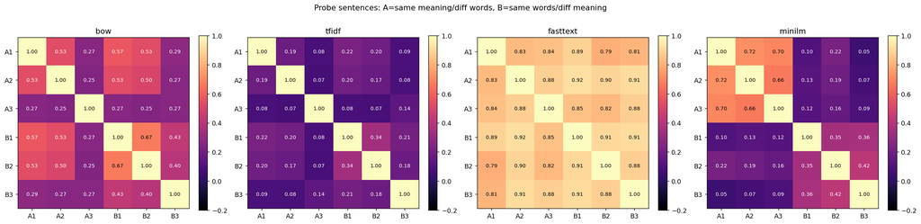

Section 9 - Probe Sentences (method-difference stress test)

**Group A - similar meaning, different words:**

- A1: "The doctor treated the patient."

- A2: "The physician helped the sick person."

- A3: "Medical care was provided to the injured man."

**Group B - similar words, different meaning:**

- B1: "The bank approved the loan."

- B2: "The fisherman sat on the bank."

- B3: "The river bank was full of stones."

Within-group mean cosine by method

| method | within-A (meaning) | within-B (shared words) | A − B |
| --- | --- | --- | --- |
| bow | 0.351 | 0.499 | -0.149 |
| tfidf | 0.11 | 0.244 | -0.133 |
| fasttext | 0.852 | 0.899 | -0.047 |
| minilm | 0.694 | 0.376 | 0.318 |

Answers

- **Best at semantic similarity** (high A, and the only positive A−B): **minilm** (within-A=0.694, A−B=0.318). It is the only method that rates the different-words/same-meaning Group A as MORE similar than the shared-word Group B.

- **Most confused by lexical overlap**: **bow** (A−B=-0.149, within-B=0.499 > within-A=0.351). The shared token "bank" makes unrelated Group B sentences look MORE similar than the genuinely-related Group A sentences.

- **Caveat - FastText**: its cosines are uniformly high (within-A=0.852, within-B=0.899); mean-pooled subword vectors push every short sentence into a similar direction, so it barely discriminates either way.

- **Largest semantic-vs-lexical gap** is for pair **A1~A3** (MiniLM − lexical = +0.52): bow=0.27, tfidf=0.08, fasttext=0.84, minilm=0.70.

  - Why: for A1~A3, MiniLM sees meaning the lexical methods miss. This is exactly where word overlap and meaning point in opposite directions, so lexical and semantic encoders disagree the most.

Full 6×6 cosine matrices

bow

|  | A1 | A2 | A3 | B1 | B2 | B3 |
| --- | --- | --- | --- | --- | --- | --- |
| A1 | 1.00 | 0.53 | 0.27 | 0.57 | 0.53 | 0.29 |
| A2 | 0.53 | 1.00 | 0.25 | 0.53 | 0.50 | 0.27 |
| A3 | 0.27 | 0.25 | 1.00 | 0.27 | 0.25 | 0.27 |
| B1 | 0.57 | 0.53 | 0.27 | 1.00 | 0.67 | 0.43 |
| B2 | 0.53 | 0.50 | 0.25 | 0.67 | 1.00 | 0.40 |
| B3 | 0.29 | 0.27 | 0.27 | 0.43 | 0.40 | 1.00 |

tfidf

|  | A1 | A2 | A3 | B1 | B2 | B3 |
| --- | --- | --- | --- | --- | --- | --- |
| A1 | 1.00 | 0.19 | 0.08 | 0.22 | 0.20 | 0.09 |
| A2 | 0.19 | 1.00 | 0.07 | 0.20 | 0.17 | 0.08 |
| A3 | 0.08 | 0.07 | 1.00 | 0.08 | 0.07 | 0.14 |
| B1 | 0.22 | 0.20 | 0.08 | 1.00 | 0.34 | 0.21 |
| B2 | 0.20 | 0.17 | 0.07 | 0.34 | 1.00 | 0.18 |
| B3 | 0.09 | 0.08 | 0.14 | 0.21 | 0.18 | 1.00 |

fasttext

|  | A1 | A2 | A3 | B1 | B2 | B3 |
| --- | --- | --- | --- | --- | --- | --- |
| A1 | 1.00 | 0.83 | 0.84 | 0.89 | 0.79 | 0.81 |
| A2 | 0.83 | 1.00 | 0.88 | 0.92 | 0.90 | 0.91 |
| A3 | 0.84 | 0.88 | 1.00 | 0.85 | 0.82 | 0.88 |
| B1 | 0.89 | 0.92 | 0.85 | 1.00 | 0.91 | 0.91 |
| B2 | 0.79 | 0.90 | 0.82 | 0.91 | 1.00 | 0.88 |
| B3 | 0.81 | 0.91 | 0.88 | 0.91 | 0.88 | 1.00 |

minilm

|  | A1 | A2 | A3 | B1 | B2 | B3 |
| --- | --- | --- | --- | --- | --- | --- |
| A1 | 1.00 | 0.72 | 0.70 | 0.10 | 0.22 | 0.05 |
| A2 | 0.72 | 1.00 | 0.66 | 0.13 | 0.19 | 0.07 |
| A3 | 0.70 | 0.66 | 1.00 | 0.12 | 0.16 | 0.09 |
| B1 | 0.10 | 0.13 | 0.12 | 1.00 | 0.35 | 0.36 |
| B2 | 0.22 | 0.19 | 0.16 | 0.35 | 1.00 | 0.42 |
| B3 | 0.05 | 0.07 | 0.09 | 0.36 | 0.42 | 1.00 |

```python
probes.main()
display(Image(str(config.RESULTS_DIR / "section_tet_probes.png")))
display(Markdown((config.RESULTS_DIR / "section_tet_probes.md").read_text()))
```

## 10 - Why can TF-IDF fail to detect semantic similarity?

TF-IDF represents a sentence as weighted counts over a **fixed vocabulary**, each word an independent, meaning-free dimension. Two sentences that mean the same thing with **different words** share few/no dimensions → near-orthogonal vectors → low cosine. IDF makes it worse by *up-weighting rare words*, so distinctive synonyms ("physician" vs "doctor") push the vectors apart instead of together. **Evidence:** TF-IDF within-Group-A (same meaning, different words) is only **0.11** (vs MiniLM 0.69), and its same-topic original↔generated cosine collapses to **0.47** at 300-dim because the generated texts restate meaning with a different, restricted vocabulary. TF-IDF has no notion of synonymy - it only matches surface tokens.

## 11 - Does a higher-dimensional embedding always give better results?

**No.** From section 6, MiniLM's topic separation *drops* from **0.824 (30-d) to 0.732 (300-d)**: the first ~30 PCA components hold the dominant semantic axes (51.8 % variance) and the extra 270 dims add mostly noise. **When the dimension is too small**, information loss is catastrophic: BoW/TF-IDF at 30 dims keep only the 30 commonest words ("the, and, of, a, …"), so all documents look alike and separation is ≈0 (BoW 0.049). Section 7 reinforces it: PCA-reduced 30 dims (information-rich) beat native top-30 dims (TF-IDF 0.13→0.40, FastText 0.15→0.86). So more dimensions help only while each new dimension still carries useful, non-redundant signal.